# Homework10

Victor Torres

2024-11-19

### Instructions

Imagine 10000 receipts sitting on your table. Each receipt represents a transaction with items that were purchased. The receipt is a representation of stuff that went into a customer’s basket - and therefore ‘Market Basket Analysis’.

That is exactly what the Groceries Data Set contains: a collection of receipts with each line representing 1 receipt and the items purchased. Each line is called a transaction and each column in a row represents an item. The data set is attached.

Your assignment is to use R to mine the data for association rules. You should report support, confidence and lift and your top 10 rules by lift.

Extra credit: do a simple cluster analysis on the data as well. Use whichever packages you like.

#### Load Libraries for this Project.

```r
library(tidyverse)
library(arules)
library(arulesViz)
library(visNetwork)
library(igraph)
```

# Methods

## A: Use R to mine the data for association rules

### Sections

#### Load DataFrame as “transaction data” to use arules library

```r
grocerydf <- read.transactions("C:/Users/vitug/OneDrive/Desktop/CUNY Masters/DATA_624/GroceryDataSet.csv", format = "basket", sep=",")

summary(grocerydf)
```

```
## transactions as itemMatrix in sparse format with
##  9835 rows (elements/itemsets/transactions) and
##  169 columns (items) and a density of 0.02609146
##
## most frequent items:
##       whole milk other vegetables       rolls/buns             soda
##             2513             1903             1809             1715
##           yogurt          (Other)
##             1372            34055
##
## element (itemset/transaction) length distribution:
## sizes
##    1    2    3    4    5    6    7    8    9   10   11   12   13   14   15   16
## 2159 1643 1299 1005  855  645  545  438  350  246  182  117   78   77   55   46
##   17   18   19   20   21   22   23   24   26   27   28   29   32
##   29   14   14    9   11    4    6    1    1    1    1    3    1
##
##    Min. 1st Qu.  Median    Mean 3rd Qu.    Max.
##   1.000   2.000   3.000   4.409   6.000  32.000
##
## includes extended item information - examples:
##             labels
## 1 abrasive cleaner
## 2 artif. sweetener
## 3   baby cosmetics
```

#### Plot top10 items using “itemFrequencyPlot” function.

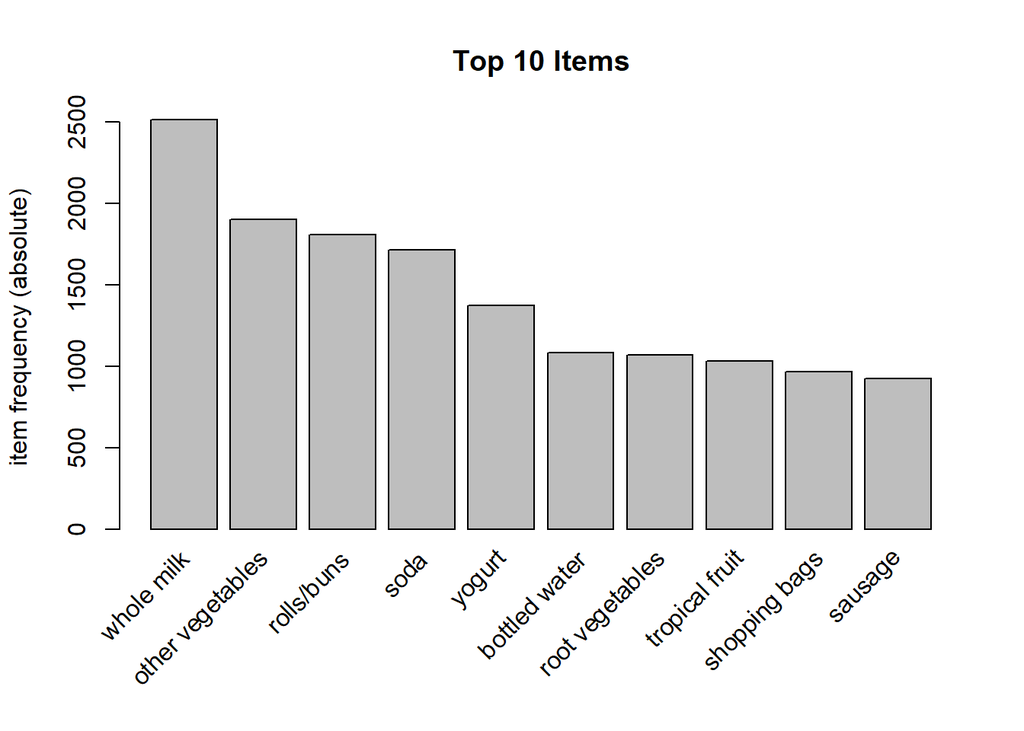

```r
itemFrequencyPlot(grocerydf, topN=10, type="absolute", main="Top 10 Items")
```

After plotting the list of transacctions, I can clearly see that whole milk, other vegetables, rolls/buns and soda were at top of purchased items based on item frequency.

#### Use the Apriori algorithm to find frequent itemsets

```r
frequent_itemsets <- apriori(grocerydf, parameter = list(supp = 0.01, conf = 0.5))
```

```
## Apriori
##
## Parameter specification:
##  confidence minval smax arem  aval originalSupport maxtime support minlen
##         0.5    0.1    1 none FALSE            TRUE       5    0.01      1
##  maxlen target  ext
##      10  rules TRUE
##
## Algorithmic control:
##  filter tree heap memopt load sort verbose
##     0.1 TRUE TRUE  FALSE TRUE    2    TRUE
##
## Absolute minimum support count: 98
##
## set item appearances ...[0 item(s)] done [0.00s].
## set transactions ...[169 item(s), 9835 transaction(s)] done [0.00s].
## sorting and recoding items ... [88 item(s)] done [0.00s].
## creating transaction tree ... done [0.00s].
## checking subsets of size 1 2 3 4 done [0.01s].
## writing ... [15 rule(s)] done [0.00s].
## creating S4 object  ... done [0.00s].
```

```r
# Inspect the frequent itemsets
inspect(frequent_itemsets)
```

```
##      lhs                                       rhs                support
## [1]  {curd, yogurt}                         => {whole milk}       0.01006609
## [2]  {butter, other vegetables}             => {whole milk}       0.01148958
## [3]  {domestic eggs, other vegetables}      => {whole milk}       0.01230300
## [4]  {whipped/sour cream, yogurt}           => {whole milk}       0.01087951
## [5]  {other vegetables, whipped/sour cream} => {whole milk}       0.01464159
## [6]  {other vegetables, pip fruit}          => {whole milk}       0.01352313
## [7]  {citrus fruit, root vegetables}        => {other vegetables} 0.01037112
## [8]  {root vegetables, tropical fruit}      => {other vegetables} 0.01230300
## [9]  {root vegetables, tropical fruit}      => {whole milk}       0.01199797
## [10] {tropical fruit, yogurt}               => {whole milk}       0.01514997
## [11] {root vegetables, yogurt}              => {other vegetables} 0.01291307
## [12] {root vegetables, yogurt}              => {whole milk}       0.01453991
## [13] {rolls/buns, root vegetables}          => {other vegetables} 0.01220132
## [14] {rolls/buns, root vegetables}          => {whole milk}       0.01270971
```

[output cut: 17 more lines]

#### Generate asociation rules

```r
rules <- apriori(grocerydf, parameter = list(supp = 0.01, conf = 0.5))
```

```
## Apriori
##
## Parameter specification:
##  confidence minval smax arem  aval originalSupport maxtime support minlen
##         0.5    0.1    1 none FALSE            TRUE       5    0.01      1
##  maxlen target  ext
##      10  rules TRUE
##
## Algorithmic control:
##  filter tree heap memopt load sort verbose
##     0.1 TRUE TRUE  FALSE TRUE    2    TRUE
##
## Absolute minimum support count: 98
##
## set item appearances ...[0 item(s)] done [0.00s].
## set transactions ...[169 item(s), 9835 transaction(s)] done [0.00s].
## sorting and recoding items ... [88 item(s)] done [0.00s].
## creating transaction tree ... done [0.00s].
## checking subsets of size 1 2 3 4 done [0.00s].
## writing ... [15 rule(s)] done [0.00s].
## creating S4 object  ... done [0.00s].
```

```r
# Inspect the rules
inspect(rules)
```

```
##      lhs                                       rhs                support
## [1]  {curd, yogurt}                         => {whole milk}       0.01006609
## [2]  {butter, other vegetables}             => {whole milk}       0.01148958
## [3]  {domestic eggs, other vegetables}      => {whole milk}       0.01230300
## [4]  {whipped/sour cream, yogurt}           => {whole milk}       0.01087951
## [5]  {other vegetables, whipped/sour cream} => {whole milk}       0.01464159
## [6]  {other vegetables, pip fruit}          => {whole milk}       0.01352313
## [7]  {citrus fruit, root vegetables}        => {other vegetables} 0.01037112
## [8]  {root vegetables, tropical fruit}      => {other vegetables} 0.01230300
## [9]  {root vegetables, tropical fruit}      => {whole milk}       0.01199797
## [10] {tropical fruit, yogurt}               => {whole milk}       0.01514997
## [11] {root vegetables, yogurt}              => {other vegetables} 0.01291307
## [12] {root vegetables, yogurt}              => {whole milk}       0.01453991
## [13] {rolls/buns, root vegetables}          => {other vegetables} 0.01220132
## [14] {rolls/buns, root vegetables}          => {whole milk}       0.01270971
```

[output cut: 17 more lines]

#### Inspect top10 rules using “lift” function

```r
inspect(sort(rules, by = "lift")[1:10])
```

```
##      lhs                                  rhs                support
## [1]  {citrus fruit, root vegetables}   => {other vegetables} 0.01037112
## [2]  {root vegetables, tropical fruit} => {other vegetables} 0.01230300
## [3]  {rolls/buns, root vegetables}     => {other vegetables} 0.01220132
## [4]  {root vegetables, yogurt}         => {other vegetables} 0.01291307
## [5]  {curd, yogurt}                    => {whole milk}       0.01006609
## [6]  {butter, other vegetables}        => {whole milk}       0.01148958
## [7]  {root vegetables, tropical fruit} => {whole milk}       0.01199797
## [8]  {root vegetables, yogurt}         => {whole milk}       0.01453991
## [9]  {domestic eggs, other vegetables} => {whole milk}       0.01230300
## [10] {whipped/sour cream, yogurt}      => {whole milk}       0.01087951
##      confidence coverage   lift     count
## [1]  0.5862069  0.01769192 3.029608 102
## [2]  0.5845411  0.02104728 3.020999 121
## [3]  0.5020921  0.02430097 2.594890 120
## [4]  0.5000000  0.02582613 2.584078 127
## [5]  0.5823529  0.01728521 2.279125  99
## [6]  0.5736041  0.02003050 2.244885 113
## [7]  0.5700483  0.02104728 2.230969 118
## [8]  0.5629921  0.02582613 2.203354 143
## [9]  0.5525114  0.02226741 2.162336 121
## [10] 0.5245098  0.02074225 2.052747 107
```

#### Find number of rules using “summary” function.

```r
summary(rules)
```

```
## set of 15 rules
##
## rule length distribution (lhs + rhs):sizes
##  3
## 15
##
##    Min. 1st Qu.  Median    Mean 3rd Qu.    Max.
##       3       3       3       3       3       3
##
## summary of quality measures:
##     support          confidence        coverage            lift
##  Min.   :0.01007   Min.   :0.5000   Min.   :0.01729   Min.   :1.984
##  1st Qu.:0.01174   1st Qu.:0.5151   1st Qu.:0.02089   1st Qu.:2.036
##  Median :0.01230   Median :0.5245   Median :0.02430   Median :2.203
##  Mean   :0.01316   Mean   :0.5411   Mean   :0.02454   Mean   :2.299
##  3rd Qu.:0.01403   3rd Qu.:0.5718   3rd Qu.:0.02598   3rd Qu.:2.432
##  Max.   :0.02227   Max.   :0.5862   Max.   :0.04342   Max.   :3.030
##      count
##  Min.   : 99.0
##  1st Qu.:115.5
##  Median :121.0
##  Mean   :129.4
##  3rd Qu.:138.0
##  Max.   :219.0
##
## mining info:
##       data ntransactions support confidence
##  grocerydf          9835    0.01        0.5
##                                                                  call
##  apriori(data = grocerydf, parameter = list(supp = 0.01, conf = 0.5))
```

#### Graph of top10 rules by “lift” using IGraph

[output not shown]

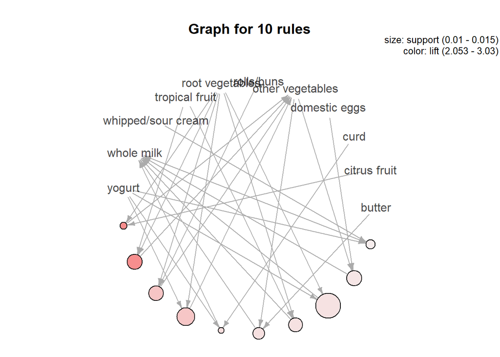

```r
plot(rules,by = "lift", method="graph", engine = "igraph", layout = igraph::in_circle(), limit = 10)
```

## B: Perform a Market Basket Analysis

### Sections

#### Create a co-occurrence matrix from the transaction data

```r
co_occurrence_matrix <- crossTable(grocerydf)

# Convert the co-occurrence matrix to a graph
g <- graph.adjacency(co_occurrence_matrix, mode = "undirected", weighted = TRUE)
# Inspect the graph
summary(g)
```

```
## IGRAPH 793b7ef UNW- 169 9805 --
## + attr: name (v/c), weight (e/n)
```

#### Create a graph displaying the top 10 items(nodes) in the network

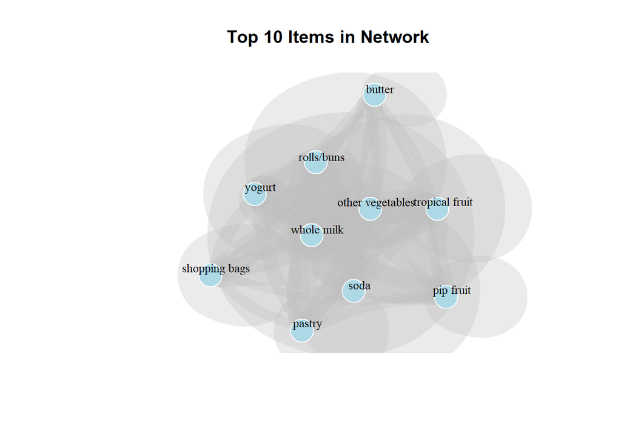

```r
# Function to plot the top 10 items (nodes) based on degree centrality
plot_top_items_network <- function(g, top_n = 10, layout_type = "fr", transparency = 0.5) {

  # Calculate degree centrality for each node
  importance_scores <- degree(g)

  # Get the top10 nodes based on degree
  top_nodes <- order(importance_scores, decreasing = TRUE)[1:top_n]

  # Create a sub graph for the top10 nodes
  top_subgraph <- induced_subgraph(g, top_nodes)

  # Use specified layout type for the network
  if (layout_type == "fr") {
    layout_fr <- layout_with_fr(top_subgraph)  # Fruchterman-Reingold layout
  } else if (layout_type == "kk") {
    layout_fr <- layout_with_kk(top_subgraph)  # Kamada-Kawai layout
  } else {
    layout_fr <- layout_in_circle(top_subgraph)  # Circle layout as fallback
  }

  # Plot the top10 items (nodes)
  plot(top_subgraph,
       layout = layout_fr,
       vertex.size = 20,               # Size of nodes
       vertex.label.cex = 0.8,         # Size of labels
       vertex.color = "lightblue",     # Color for all nodes
       vertex.frame.color = "white",   # White frame around nodes
       edge.width = E(top_subgraph)$weight / 10,  # Width of edges
       edge.color = adjustcolor("gray", alpha.f = transparency), # Transparent edges
       edge.arrow.size = 1.5,          # Size of edge arrows
       main = paste("Top", top_n, "Items in Network"),
       vertex.label.color = "black",   # Label color
       vertex.label.dist = 1,          # Label distance from node
       edge.curved = 0.2)              # Curved edges
}

plot_top_items_network(g, top_n = 10, layout_type = "fr", transparency = 0.3)
```

Based on the graph above, whole milk and yogurt has a direct relationship as well as other vegetables and roll-buns, shopping bags, pastry and butter are more independent items in the top10 network.

#### Create a communtity detection using the “Louvain method”

```r
communities <- cluster_louvain(g)

membership(communities)
```

```
##          abrasive cleaner          artif. sweetener            baby cosmetics
##                         1                         2                         1
##                 baby food                      bags             baking powder
##                         3                         4                         2
##          bathroom cleaner                      beef                   berries
##                         1                         5                         6
##                 beverages              bottled beer             bottled water
##                         7                         8                         8
##                    brandy               brown bread                    butter
##                         9                        10                        11
##               butter milk                  cake bar                   candles
##                        12                         3                         2
##                     candy               canned beer               canned fish
##                        13                         9                        14
##              canned fruit         canned vegetables                  cat food
##                        14                        15                         1
##                   cereals               chewing gum                   chicken
##                        12                         9                        16
##                 chocolate     chocolate marshmallow              citrus fruit
##                        13                        13                        17
##                   cleaner           cling film/bags              cocoa drinks
##                         1                         1                         2
##                    coffee            condensed milk         cooking chocolate
##                         1                         1                         2
##                  cookware                     cream              cream cheese
##                        13                        18                        12
##                      curd               curd cheese               decalcifier
##                        12                         1                        19
##               dental care                   dessert                 detergent
##                        20                         3                        19
##              dish cleaner                    dishes                  dog food
##                         1                        21                        22
##             domestic eggs  female sanitary products         finished products
##                        11                         1                        13
##                      fish                     flour            flower (seeds)
##                         1                         2                        16
##    flower soil/fertilizer               frankfurter            frozen chicken
##                        19                        14                         3
##            frozen dessert               frozen fish             frozen fruits
##                        18                        18                         6
```

[output cut: 59 more lines]

```
##                         2                        24                        16
##             spread cheese                     sugar             sweet spreads
##                         4                         2                        15
##                     syrup                       tea                   tidbits
##                         1                         8                         4
##            toilet cleaner            tropical fruit                    turkey
##                        20                        17                        22
##                  UHT-milk                   vinegar                   waffles
##                         1                         2                        13
##        whipped/sour cream                    whisky               white bread
##                         6                         9                        24
##                white wine                whole milk                    yogurt
##                         8                        25                        12
##                  zwieback
##                        21
```

#### Create a Plot with the top3 communities with its items

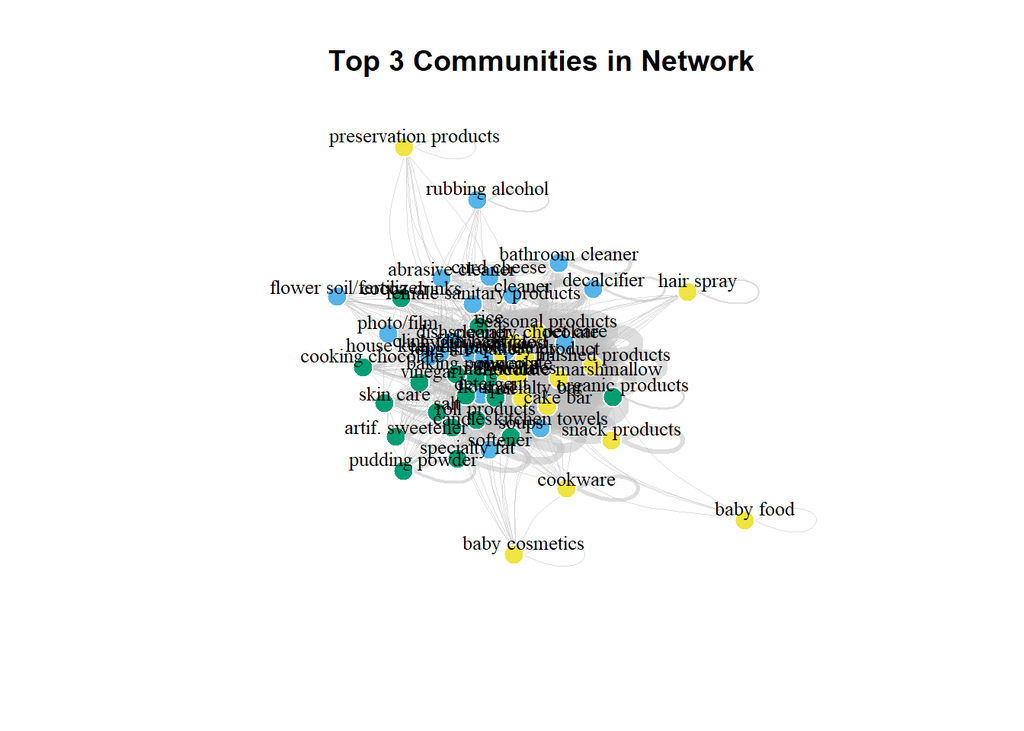

```r
# Function to plot the top 10 communities in the network
plot_top_communities_network <- function(g, top_n = 3, layout_type = "fr", transparency = 0.5) {

  # Perform community detection using the Louvain method
  communities <- cluster_louvain(g)

  # Get community membership (which community each node belongs to)
  community_membership <- membership(communities)

  # Identify the top N communities based on size (number of nodes)
  community_sizes <- table(community_membership)
  top_communities <- order(community_sizes, decreasing = TRUE)[1:top_n]

  # Create a subgraph that includes only the nodes in the top N communities
  nodes_in_top_communities <- which(community_membership %in% top_communities)
  top_community_subgraph <- induced_subgraph(g, nodes_in_top_communities)

  # Use specified layout type for the network
  if (layout_type == "fr") {
    layout_fr <- layout_with_fr(top_community_subgraph)  # Fruchterman-Reingold layout
  } else if (layout_type == "kk") {
    layout_fr <- layout_with_kk(top_community_subgraph)  # Kamada-Kawai layout
  } else {
    layout_fr <- layout_in_circle(top_community_subgraph)  # Circle layout as fallback
  }

  # Plot the network of the top N communities
  plot(top_community_subgraph,
       layout = layout_fr,
       vertex.size = 10,               # Size of nodes
       vertex.label.cex = 0.8,         # Size of labels
       vertex.color = community_membership[nodes_in_top_communities] + 1,  # Color by community
       vertex.frame.color = "white",   # White frame around nodes
       edge.width = E(top_community_subgraph)$weight / 10,  # Width of edges
       edge.color = adjustcolor("gray", alpha.f = transparency), # Transparent edges
       edge.arrow.size = 0.5,          # Size of edge arrows
       main = paste("Top", top_n, "Communities in Network"),
       vertex.label.color = "black",   # Label color
       vertex.label.dist = 1,          # Label distance from node
       edge.curved = 0.3)              # Curved edges
}
# Plot the top 10 communities in the network
plot_top_communities_network(g, top_n = 3, layout_type = "fr", transparency = 0.5)
```

#### Create a Plot to display, top5 communities and items(nodes)

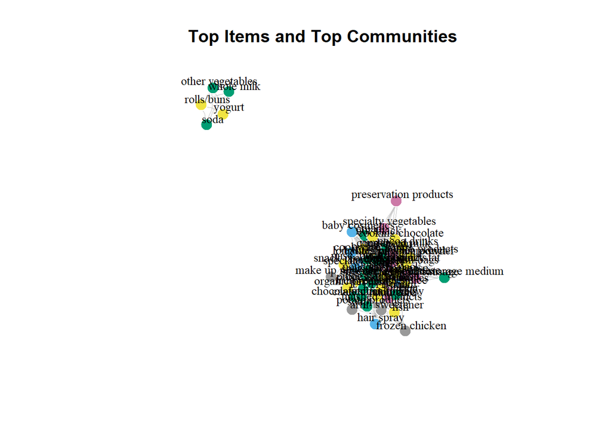

```r
# Function to plot top items and top communities together
plot_top_items_and_communities <- function(g, top_items_n = 5, top_communities_n = 5, layout_type = "fr", transparency = 0.5) {

  # Calculate degree centrality for each node (for top items)
  importance_scores <- degree(g)
  top_items <- order(importance_scores, decreasing = TRUE)[1:top_items_n]

  # Perform community detection
  communities <- cluster_louvain(g)
  community_membership <- membership(communities)

  # Get community sizes and top N communities based on size
  community_sizes <- table(community_membership)
  top_communities <- order(community_sizes, decreasing = TRUE)[1:top_communities_n]

  # Subgraph for top items
  top_items_subgraph <- induced_subgraph(g, top_items)

  # Subgraph for top communities
  nodes_in_top_communities <- which(community_membership %in% top_communities)
  top_communities_subgraph <- induced_subgraph(g, nodes_in_top_communities)

  # Combine the two subgraphs (top items and top communities)
  combined_subgraph <- union(top_items_subgraph, top_communities_subgraph)

  # Plot combined subgraph
  layout_fr <- layout_with_fr(combined_subgraph)
  plot(combined_subgraph,
       layout = layout_fr,
       vertex.size = 10,               # Size of nodes
       vertex.label.cex = 0.8,         # Size of labels
       vertex.color = community_membership[nodes_in_top_communities] + 1,  # Color by community
       vertex.frame.color = "white",   # White frame around nodes
       edge.width = E(combined_subgraph)$weight / 10,  # Width of edges
       edge.color = adjustcolor("gray", alpha.f = transparency), # Transparent edges
       edge.arrow.size = 0.7,          # Size of edge arrows
       main = paste("Top Items and Top Communities"),
       vertex.label.color = "black",   # Label color
       vertex.label.dist = 1,          # Label distance from node
       edge.curved = 0.3)              # Curved edges
}
# Plot the top 10 items and the top 10 communities together
plot_top_items_and_communities(g, top_items_n = 5, top_communities_n = 5, layout_type = "fr", transparency = 0.5)
```

The graph above is a bit messy, however, we can see items that are more independent such as soda,whole milk, bun-rolls.

#### Create a function to analysis of top10 items based on degree and centrality

```r
# Function to plot the top N most important items in the network
plot_top_items_network <- function(g, criterion = "degree", top_n = 10, layout_type = "fr", transparency = 0.3) {

  # Check criterion and calculate corresponding values (degree, betweenness, etc.)
  if (criterion == "degree") {
    importance_scores <- degree(g)
  } else if (criterion == "betweenness") {
    importance_scores <- betweenness(g)
  } else if (criterion == "closeness") {
    importance_scores <- closeness(g)
  } else {
    stop("Unknown criterion. Please choose 'degree', 'betweenness', or 'closeness'.")
  }

  # Get the top N nodes based on the selected criterion
  top_nodes <- order(importance_scores, decreasing = TRUE)[1:top_n]

  # Create a subgraph for the top N nodes
  top_subgraph <- induced_subgraph(g, top_nodes)

  # Perform community detection on the subgraph
  communities_subgraph <- cluster_louvain(top_subgraph)

  # Use specified layout type for the subgraph
  if (layout_type == "fr") {
    layout_fr <- layout_with_fr(top_subgraph)  # Fruchterman-Reingold layout
  } else if (layout_type == "kk") {
    layout_fr <- layout_with_kk(top_subgraph)  # Kamada-Kawai layout
  } else {
    layout_fr <- layout_in_circle(top_subgraph)  # Circle layout as fallback
  }

  # Plot the network with selected settings
  plot(top_subgraph,
       layout = layout_fr,
       vertex.size = 10,               # Size of nodes
       vertex.label.cex = 0.8,         # Size of labels
       vertex.color = membership(communities_subgraph) + 1,  # Color by community membership
       vertex.frame.color = "white",   # White frame around nodes
       edge.width = E(top_subgraph)$weight / 10,    # Width of edges
       edge.color = adjustcolor("gray", alpha.f = transparency), # Transparent edges
       edge.arrow.size = 0.5,          # Size of edge arrows
       main = paste("Top", top_n, "Items by", criterion),
       vertex.label.color = "black",   # Label color
       vertex.label.dist = 1,          # Label distance from node
       edge.curved = 0.2)              # Curved edges
}
```

#### Graph of top10 items by degree

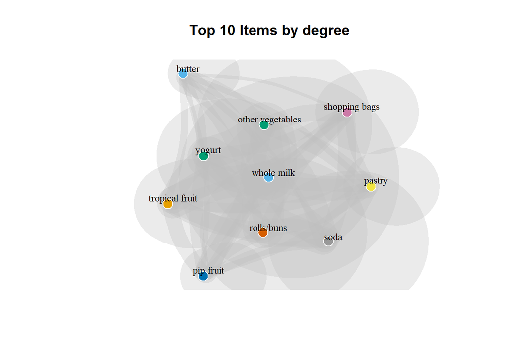

```r
plot_top_items_network(g, criterion = "degree", top_n = 10, layout_type = "fr", transparency = 0.3)
```

#### Plot of top10 items by betweenness

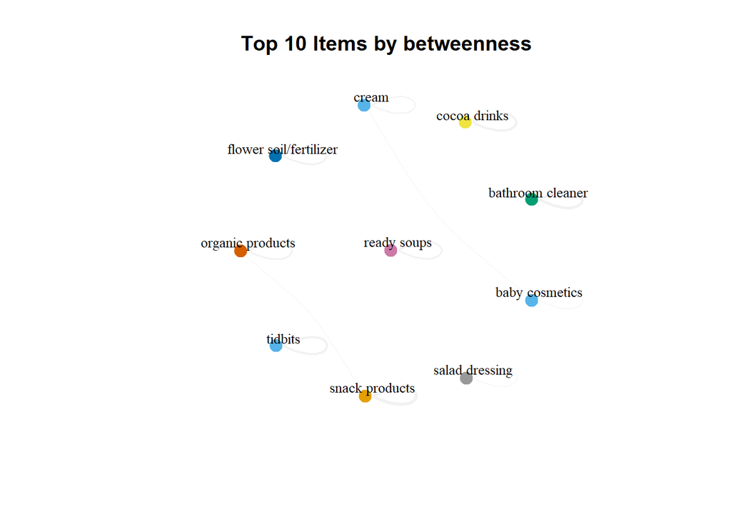

```r
# Plot the top 10 most central items (based on betweenness centrality)
plot_top_items_network(g, criterion = "betweenness", top_n = 10, layout_type = "kk", transparency = 0.2)
```

Based on the last analysis, the top items on the list are whole milk and other vegetables, there’s a different result when I get the top10 items by betweenness with ready soups as the main item. The results varies based on the analysis type, I am really glad that I made this portion of the project, because I just realized that I can use several approaches based on project’s needs with market basket analysis.